# Machine Learning Lab Solutions

4. Which categories (sub-categories) of products are more likely to be returned?

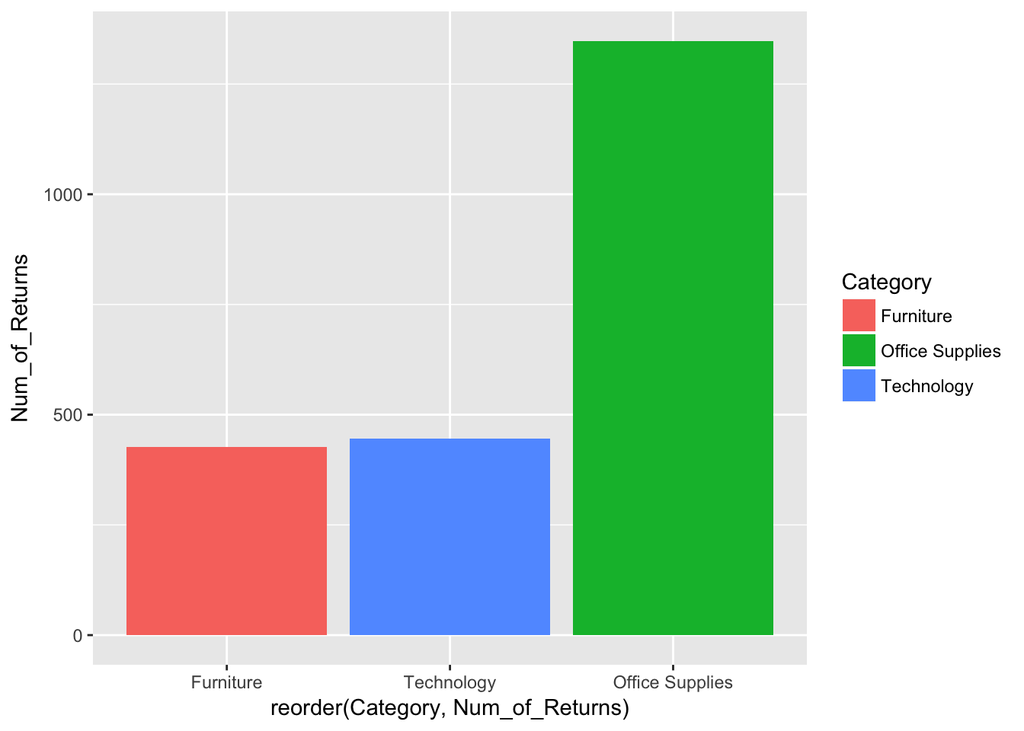

```r
# Your code here
Pro_cat <- returns %>%
  group_by(Category,Sub.Category) %>%
  summarise(Num_of_Returns=n()) %>%
  arrange(desc(Num_of_Returns))

# By Category
ggplot(Pro_cat, aes(x=reorder(Category, Num_of_Returns), y=Num_of_Returns)) +
  geom_bar(aes(fill=Category), stat="identity")
```

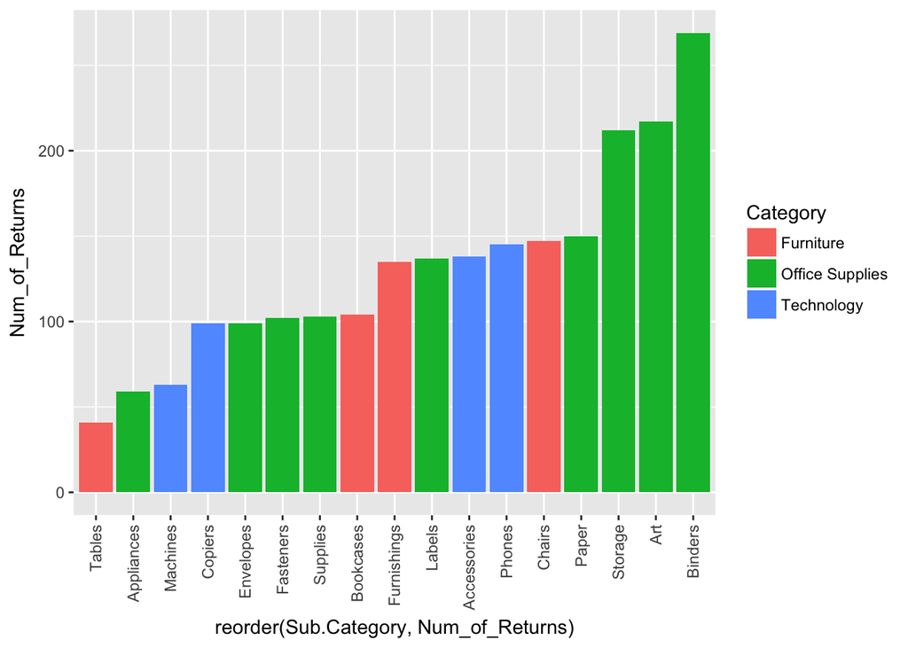

```r
# By Sub.Category
ggplot(Pro_cat, aes(x=reorder(Sub.Category, Num_of_Returns), y=Num_of_Returns)) +
  geom_bar(aes(fill=Category), stat="identity") +
  theme(axis.text.x=element_text(angle=90, hjust=1, vjust=0.5))
```

Office supplies was the category that got returned the most.

## Part II: Machine Learning and Business Use-Case

Now your manager has a basic idea of why customers returned orders. Next, he wants you to use machine learning to predict which orders are most likely to be returned. In this part, you will generate several features based on our previous findings and your manager’s requirements.

### Problem 4: Feature Engineering

#### Step 1: Create the dependent variable

First of all, we need to generate a categorical variable which indicates whether an order has been returned or not.

*Hint*: the returned orders’ IDs are contained in the dataset “returns”

```r
# Your code here
orders$Returned = ifelse(orders$Order.ID %in% returns$Order.ID,"Yes","No")
```

#### Step 2:

- Your manager believes that **how long it took the order to ship** would affect whether the customer would return it or not.
- He wants you to generate a feature which can measure how long it takes the company to process each order.

*Hint*: Process.Time = Ship.Date - Order.Date

```r
# Your code here
orders$Ship.Date<-as.Date(orders$Ship.Date,"%m/%d/%y")
orders$Process.Time<-as.numeric(orders$Ship.Date-orders$Order.Date)
```

#### Step 3:

- If a product has been returned previously, it may be returned again.
- Let us generate a feature indictes how many times the product has been returned before.
- If it never got returned, we just impute using 0.

*Hint*: Group by different Product.ID

```r
# Your code here
Product <- orders%>%
group_by(Product.ID)%>%
summarise(Return.Times=n())

orders<-left_join(orders,Product,by=c("Product.ID"))
orders$Return.Times[is.na(orders$Return.Times)] <- 0
```